# Methylation data analysis

Mikhail Dozmorov, Ph.D.  
mikhail.dozmorov@vcuhealth.org

http://rpubs.com/mdozmorov/methylation

## DNA methylation

- DNA methylation is a type of chemical modification of DNA which involves the addition of a methyl group to the number 5 carbon of the cytosine (5C), to convert cytosine to 5-methylcytosine (5mC).
- The most well characterized epigenetic mechanism.
- In humans, DNA methylation occurs in cytosines that precede guanines (hence, CpG)

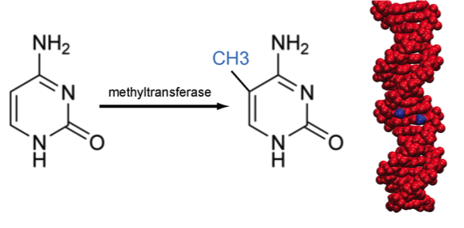

## DNA modifications

- Other nucleotides (Adenine, Guanine, Thymine) also modified

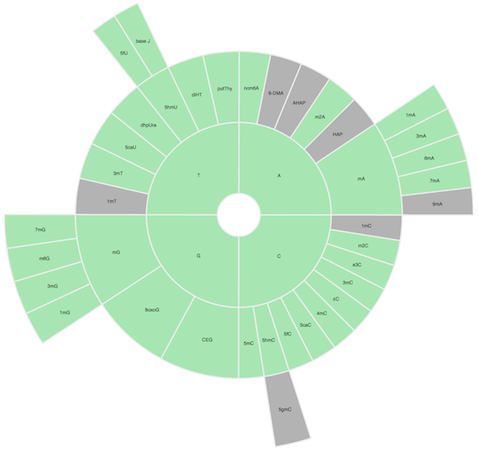

Sood AJ, Viner C, Hoffman MM. 2016. "**DNAmod: the DNA modification database.**" bioRxiv 071712. https://www.pmgenomics.ca/hoffmanlab/proj/dnamod/

## CpG Sites and CpG islands

- CpG sites are not randomly distributed in the genome - the frequency of CpG sites in human genomes is 1%, which is less than the expected (~4-6%).
- Around 60-90% of CpGs are methylated in mammals.
- DNA methylation frequently occurs in repeated sequences, and may help to suppress transcription from repeated sequences, and aid chromosomal stability.

## CpG Sites and CpG islands

- There are regions of the DNA that have a higher concentration of CpG sites (> 60%), named the CpG islands, which tend to be located in the promoter regions of many genes.
- Between 200-1000 bp in length
- Usually not methylated.

## Creation and maintenance of DNA methylation

- In humans, DNA is methylated by three enzymes, DNA methyltransferase DNMT1, DNMT3a, DNMT3b.
- DNMT1 is the maintenance methyltransferase that is responsible for copying DNA methylation patterns to the daughter strands during DNA replication.
- DNMT3a and 3b are the *de novo* methyltransferases that set up DNA methylation patterns early in development.

## Roles of DNA methylation

- Transcriptional gene silencing
- Maintain genome stability
- Embryonic development
- Genomic imprinting
- X chromosome inactivation (females)

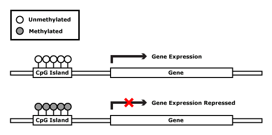

## Factors associated with changes in DNA methylation

- Aging (developmental stage)
- Diet
- Inflammatory patterns
- Environmental exposures
- Smoking
- Alcohol

## DNA methylation and cancer

**Hypomethylation** – decrease methylation levels

- A lower level of DNA methylation in tumors was one of the first epigenetic alterations to be found in human cancer. (Feinberg AP, et al., 1983).
- Demethylation of the promoter region of proto-oncogenes will activate normally repressed gene expression
- Global hypomethylation of DNA sequences that are normally heavily methylated may result in:
  - Chromosomal instability
  - Increased transcription from transposable elements
  - An elevated mutation rate due to mitotic recombination

## DNA hypermethylation

**Hypermethylation** – increase methylation levels

- Hypermethylation of the CpG islands in the promoter regions of tumor-suppressor genes is a major event in the origin of many cancers.
- Hypermethylation of promoters can inactivate tumor-suppressor genes, affect genes involved in the cell cycle, DNA repair, and the metabolism of carcinogens, all of which are involved in the development of cancer.
- The profiles of hypermethylation of the CpG islands in tumor-suppressor genes are specific to the cancer type.

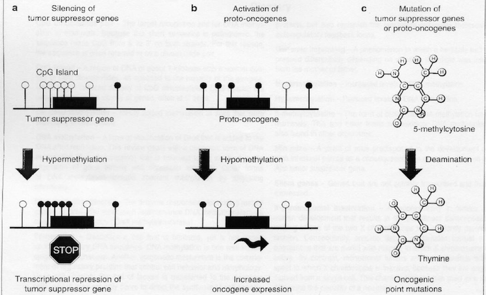

Laird PW "**Oncogenic mechanisms mediated by DNA methylation.** " Mol Med Today. 1997 http://www.cell.com/moltod/pdf/S1357-4310(97)01019-8.pdf

## Methylation assays

**Sensitivity of restriction enzymes for methylated CpG sites**

**MeDIP (Methylated DNA immuno-precipitation)**

- Anti-methylcytidine Ab to Me-C => ChIP – chip
- Doesn’t distinguish among nearby sites

## Methylation assays

**Sodium Bisulfite conversion**

- Modifies non-methylated cytosines
- Differentiation of methylated and non-methylated cytosines
- \(C \; \rightarrow \; U\)
- \(C^M \; \rightarrow \; C\)

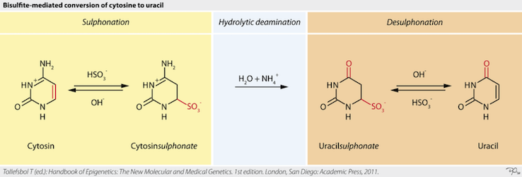

## (m)RRBS: (multiplexed) Reduced Representation Bisulfite Sequencing

- Utilizes cutting pattern of MspI enzyme (C^CGG) to systematically digest CpG-poor DNA
- Covers the majority of CpG islands and promoters, and a reasonable number of exons, shores and enhancers
- Advantages:
  - Only need 50-200ng DNA
  - Can be from any species
  - Cost and time

## Application of DNA methylation assays

**Early diagnosis**

- Detection of CpG-island hypermethylation in biological fluids and serum

**Prognosis**

- Hypemethylation of specific genes
- Whole DNA methylation profiles

**Prediction**

- CpG island hypermethylation as a marker of response to chemotherapy

**Prevention**

- Developing DNMTs inhibitors as chemopreventive drugs to reactive silenced genes

## Bisulfite conversion-based Microarray Analysis

- A DNA microarray is a technology that consists of thousands of spots with DNA oligonucleotides (probes) that are used to hybridize a target sequence.
- Probe-target hybridization is usually detected and quantified by detection of fluorophore-, or chemiluminescence-labeled targets.

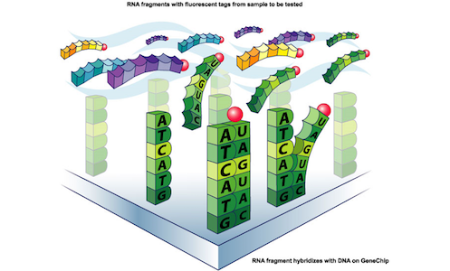

## Illumina Infinium methylation assay

- Unmethylated **cytosines** are chemically deaminated to **uracil** in the presence of bisulfite.
- Methylated cytosines are refractory to the effects of bisulfite and remain cytosine.
- After bisulfite conversion, each sample is whole-genome amplified (WGA) and enzymatically fragmented.
- The bisulfite-converted WGA-DNA samples is purified and applied to the BeadChips.

## Illumina Infinium methylation assay

- Bead technology
- Each bead has oligos containing 23-base address + 50-base probe complementary to bisulfite converted DNA

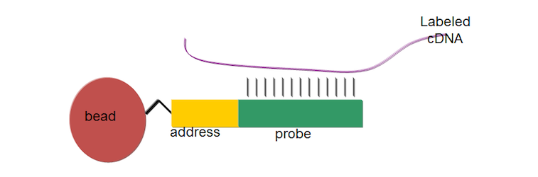

## Illumina Infinium evolution

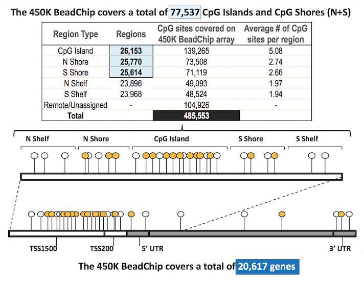

## Measurement of methylation level

Two types of probes

- **Type I probes** have two separate probe sequences per CpG site (one each for methylated and unmethylated CpGs). ~28% of probes. Suggested to be more stable and reproducible than the Type II probes
- **Type II probes** have just one probe sequence per CpG site. Use half of the physical space. ~ 72% of probes. Have a decreased quantitative dynamic range compared to Type I probes.

## Measurement of methylation level

**Beta-value**

\[\beta = \frac{M}{U + M}\]

- \(M\) - signal from methylated probes
- \(U\) - signal from unmethylated probes

\(\beta = 0\) - all probes are non-methylated

\(\beta = 1\) - all probes are methylated

## Measurement of methylation level

**Beta-value**

\[\beta = \frac{M}{U + M}\]

- \(M\) - signal from methylated probes
- \(U\) - signal from unmethylated probes

**M-value**

\[Mvalue=log \left( \frac{M}{U} \right)\]

\(M = - \infty\) - all probes are non-methylated

\(M = + \infty\) - all probes are methylated

## Measurement of methylation level

- \(\beta\) values obtained from Infinium II probes are slightly less accurate and reproducible than those obtained from Infinium I probes (Dedeurwaerder et.al. 2011)
- Peak correction methods (normalization) are available

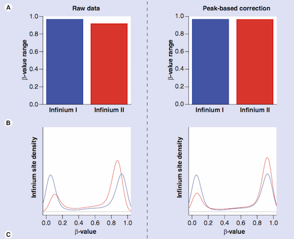

## Filter questionable probes

- Remove probes that have failed to hybridize (detection p-value)
  - detection p-value represents the probability the target signal was distinguishable against background noise
- Common approaches
  - Drop probes that failed in \(n^{th}%\) of samples
    - Common thresholds are 20%, 10%, 5% of probes at >0.05, >0.01
  - Drop samples that failed in \(n^{th}%\) of probes
    - Common thresholds are 50%, 20% at >0.05, >0.01

## Filter questionable probes

- Probes on X and Y chromosomes
- Probes with lowest variation
- Probes with extreme methylation level (e.g. median = 0% or 100%)
- Keep only those in regions of interest (e.g. CpG islands, shores)

## Filter questionable probes

- A list of potential nonspecific probes and polymorphic probes of Illumina Human 27k Methylation Array, [BrainCloud](http://braincloud.jhmi.edu/downloads.htm), http://braincloud.jhmi.edu/NonspecificAndPolymorphic.zip
- Data from Chen YA, et.al. "[Discovery of cross-reactive probes and polymorphic CpGs in the Illumina Infinium HumanMethylation450 microarray](http://www.ncbi.nlm.nih.gov/pmc/articles/PMC3592906/)." Epigenetics.
  - [List of non-specific probes](http://www.sickkids.ca/MS-Office-Files/Research/Weksberg%20Lab/48639-non-specific-probes-Illumina450k.xlsx) - 29,233 non-specific 'cg' probes, 1,736 non-specific 'ch' probes;
  - [List of polymorphic CpGs](http://www.sickkids.ca/MS-Office-Files/Research/Weksberg%20Lab/48640-polymorphic-CpGs-Illumina450k.xlsx) - 70,899 records (66,877 unique probes) about CpGs containing SNPs at or near single base extension (SBE) position, 316,034 records (220,582 unique probes) having SNPs in probe sequences.
- More for MethylationEPIC at https://genomebiology.biomedcentral.com/articles/10.1186/s13059-016-1066-1

## minfi

- Reads Illumina’s 450k array raw data (IDAT files) into R
- Performs QC and normalization
- Identifies differential methylation positions (DMP)

```r
source("https://bioconductor.org/biocLite.R")
biocLite("minfi")
biocLite("minfiData")
```

```r
library(minfi)
```

```
## locfit 1.5-9.1    2013-03-22
```

```
## Setting options('download.file.method.GEOquery'='auto')
```

```
## Setting options('GEOquery.inmemory.gpl'=FALSE)
```

## Methylation data

```r
baseDir <- system.file("extdata", package = "minfiData")
list.files(baseDir)
```

```
## [1] "5723646052"      "5723646053"      "SampleSheet.csv"
```

```r
targets <- read.metharray.sheet(baseDir)
```

```
## [read.metharray.sheet] Found the following CSV files:
```

```
## [1] "/Users/mdozmorov/Library/R/3.3/library/minfiData/extdata/SampleSheet.csv"
```

```r
RGset <- read.metharray.exp(targets = targets)
pd <- pData(RGset) ## phenotypic data
```

## QC

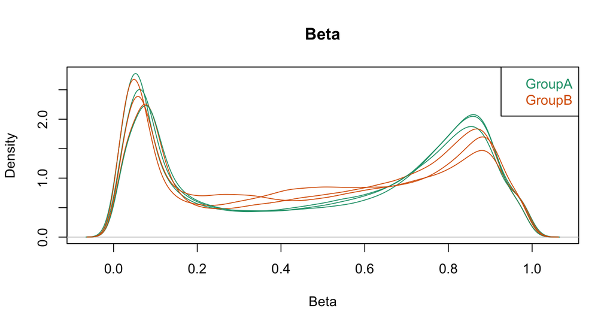

```r
densityPlot(RGset, sampGroups = pd$Sample_Group, main = "Beta", xlab = "Beta")
```

Beta values are expected to cluster around 0 or 1.

## QC

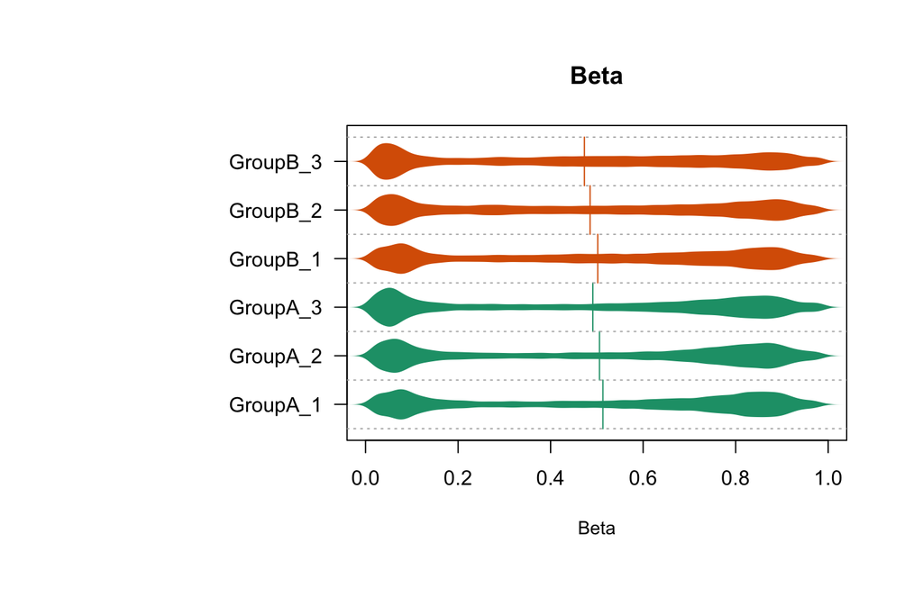

```r
par(oma=c(2,10,1,1))
densityBeanPlot(RGset, sampGroups = pd$Sample_Group, sampNames = pd$Sample_Name)
```

## Normalization

```r
MSet.norm <- preprocessIllumina(RGset, bg.correct = TRUE, normalize = "controls", reference = 2)
```

Different methods for normalization have been proposed and still being developed

- Dye-bias adjustment
- Probe type I and II adjustment

Yousefi P. et. al. "**Considerations for normalization of DNA methylation data by Illumina 450K BeadChip assay in population studies**" Epigenetics 2013 http://www.tandfonline.com/doi/abs/10.4161/epi.26037

## Multi-dimensional scaling (MDS) plot

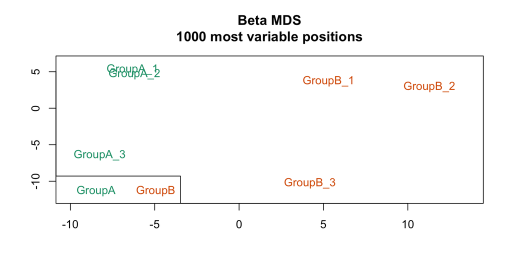

```r
mdsPlot(MSet.norm, numPositions = 1000, sampGroups = pd$Sample_Group, sampNames =pd$Sample_Name)
```

Similar to PCA, useful to identify outlier samples.

## Getting M-values

```r
## A small subset to speed up the demo:
mset <- MSet.norm[1:20000,]

## Getting the M values:
M <- getM(mset, type = "beta", betaThreshold = 0.001)
```

M values show the level of methylation centered around 0

Beta values ≤ 0.001, or more than 0.999 are truncated to avoid numerical issues.

## Differentially methylated positions

```r
dmp <- dmpFinder(M, pheno=pd$Sample_Group, type="categorical")
head(dmp)
```

```
##            intercept         f         pval       qval
## cg10805483 -9.964341 1706.1212 2.053224e-06 0.02639720
## cg20386875 -5.434480 1445.1107 2.859882e-06 0.02639720
## cg07155336 -5.799521  550.9746 1.952772e-05 0.05148498
## cg13059719 -2.505878  549.6611 1.962059e-05 0.05148498
## cg08343042 -3.565042  506.2230 2.310839e-05 0.05148498
## cg23098069  1.532107  497.6219 2.390872e-05 0.05148498
```

Rows ordered by p-value.

## Plotting methylation levels

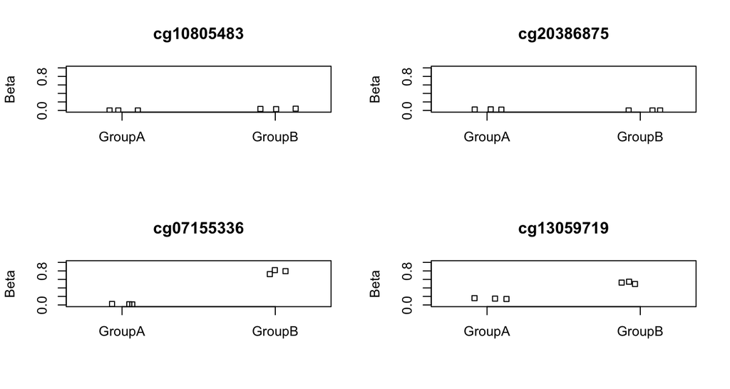

```r
cpgs <- rownames(dmp)[1:4]
par(mfrow=c(2,2))
plotCpg(mset, cpg=cpgs, pheno=pd$Sample_Group)
```

## My pipeline

1. Filtering non-specific, polymorphic, SNP, chromosome Y probes
2. Pre-processing and QC
   - `dasen` (background correction and quantile normalization)
   - `BIMQ` (Beta-mixture quantile normalization, correcting batch effect of Infinium I and II chemistries)
   - Principal Components Analysis to detect batch effects
   - `ComBat`, `ISVA` (removing batch effect)
3. Association analysis, or differential methylation
   - `betareg` regression model
   - Pearson correlation coefficient
   - `limma`, `minfi` for differentially methylated tegions
   - Benjamini-Hochberg adjusted p-values < 0.05
4. Functional enrichment analyses

## Interpretation

- Map CpG sites of interest to the nearby genes, analyze genes for functional enrichment
- Analyze genomic location of CpG sites, using genomic coordinates
  - **GREAT** predicts functions of cis-regulatory regions, http://bejerano.stanford.edu/great/public/html/
  - **Enrichr**, gene- and genomic regions enrichment analysis tool, http://amp.pharm.mssm.edu/Enrichr/#
  - **GenomeRunner**, Functional interpretation of SNPs (any genomic regions) within regulatory/epigenomic context, http://integrativegenomics.org/

## R packages for Illumina Infinium array analysis

- **lumi** - normalization, vusualization, gene annotation https://www.bioconductor.org/packages/release/bioc/html/lumi.html
- **methylumi** - normalization and general data handling http://www.bioconductor.org/packages/release/bioc/html/methylumi.html
- **minfi** - normalization, analysis and visualization http://www.bioconductor.org/packages/release/bioc/html/minfi.html, or **ChAMP** - eight functions to run *minfi* pipelines, https://bioconductor.org/packages/release/bioc/html/ChAMP.html
- **RnBeads** - works for 450K arrays, BS-Seq, MeDIP or MBD-Seq data https://bioconductor.org/packages/release/bioc/html/RnBeads.html
- **wateRmelon** - 15 normalization methods, other QC metrics https://bioconductor.org/packages/release/bioc/html/wateRmelon.html

Morris TJ, Beck S "**Analysis pipelines and packages for Infinium HumanMethylation450 BeadChip (450k) data**" Methods. 2015 https://www.ncbi.nlm.nih.gov/pmc/articles/PMC4304832/

## R packages for Illumina Infinium array analysis

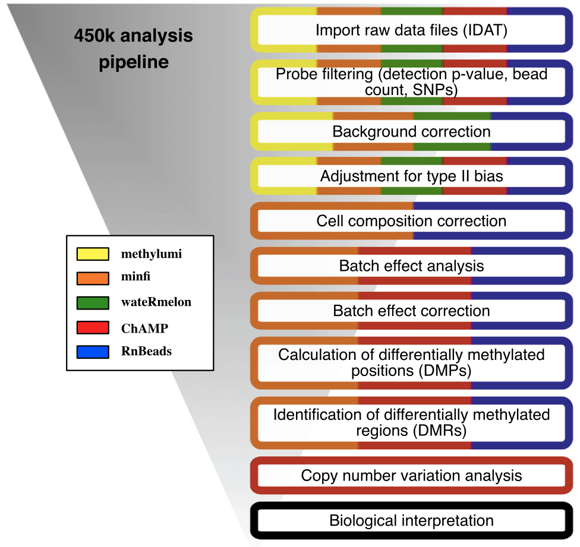

Morris TJ, Beck S "**Analysis pipelines and packages for Infinium HumanMethylation450 BeadChip (450k) data**" Methods. 2015 https://www.ncbi.nlm.nih.gov/pmc/articles/PMC4304832/

## Methylation statistics packages

- **BiSeq** (K. Hebestreit et al.) Beta regression model, impractical for very large data other than RRBS or targeted BS-Seq https://bioconductor.org/packages/release/bioc/html/BiSeq.html
- **bsseq** (K.D. Hansen) Implements the BSmooth smoothing algorithm. Numerous CpG-wise t-tests and p-value cutoff to define DMRs. Outperforms Fisher’s exact test. Requires biological replicates for DMR detection https://bioconductor.org/packages/release/bioc/html/bsseq.html
- **DMAP** (P. Stockwell et al.) RRBS fragment or fixed window approach, Fisher’s exact test, Chi-squared or ANOVA RADMeth (C++ command line tool by E. Dolzhenko and A.D. Smith) Beta-binomial regression analysis to find DMCs or DMRs, local likelihood, adjust for neighbouring CpGs http://biochem.otago.ac.nz/research/databases-software
- **DSS** (Feng et al., 2014) Constructs genome-wide prior distribution for beta-binomial dispersion. Bayesian hierarchical model to detect differentially methylated loci https://www.bioconductor.org/packages/3.3/bioc/html/DSS.html
- **methylKit** (A. Akalin et al.) Sliding window, Fisher’s exact test or logistic regression. Adjusts p-values to q-values using SLIM method. https://github.com/al2na/methylKit
- **MOABS** (D. Sun et al.) Beta binomial hierarchical model to capture sampling and biological variation, Credible Methylation Difference (CDIF) single metric that combines biological and statistical significance https://code.google.com/archive/p/moabs/
- **methyLiftover** - map bisulfite sequencing data to the Illumina 450K methylation CpG set https://github.com/Christensen-Lab-Dartmouth/methyLiftover

## References

- Pidsley, R., et. al., and Susan J. Clark. "**Critical Evaluation of the Illumina MethylationEPIC BeadChip Microarray for Whole-Genome DNA Methylation Profiling.**"" Genome Biology 2016 https://genomebiology.biomedcentral.com/articles/10.1186/s13059-016-1066-1
- Pan D., et. al. "**Comparison of Beta-value and M-value methods for quantifying methylation levels by microarray analysis.**" BMC Bioinformatics, 2010 https://bmcbioinformatics.biomedcentral.com/articles/10.1186/1471-2105-11-587
- Methylation statistics packages: Table 2 in Liu, Hongbo, Song Li, Xinyu Wang, Jiang Zhu, Yanjun Wei, Yihan Wang, Yanhua Wen, et al. “**DNA Methylation Dynamics: Identification and Functional Annotation.**” Briefings in Functional Genomics, 2016. https://www.ncbi.nlm.nih.gov/pubmed/27515490

## Thank you

Questions?

This presentation on GitHub:

https://github.com/mdozmorov/presentations

Mikhail Dozmorov, Ph.D.

Assistant professor, Department of Biostatistics, VCU

mikhail.dozmorov@vcuhealth.org